# Classificació atès al motiu de desplaçament dels conductors ferits en accidents de trànsit a Barcelona (2023)

També procedim a codificar una nova variable a partir del mes en que es produí l’accident, tot classificant-los pels trimestres corresponents a les estacions de l’any: *Hivern*, *Primavera*, *Estiu* i *Tardor*.

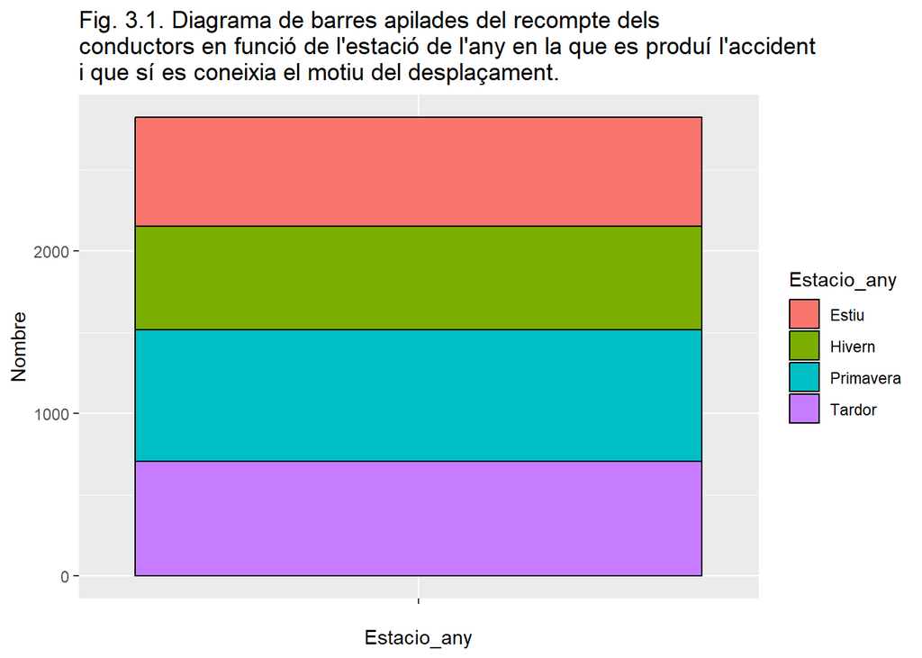

```r
dades_['Estacio_any'] <- "Estiu"
dades_$Estacio_any[dades_$Mes_any <= 3] <- "Hivern"
dades_$Estacio_any[dades_$Mes_any > 3 & dades_$Mes_any <= 6] <- "Primavera"
dades_$Estacio_any[dades_$Mes_any > 9] <- 'Tardor'

aggEstacions <- aggregate(dades_$Numero_expedient,
                             by=dades_["Estacio_any"],
                             FUN=length)

ggplot(aggEstacions, aes(x="", y=x, fill=Estacio_any)) +
  geom_bar(width = 1, stat = "identity", color = "black") +
  ggtitle(glue("Fig. 3.1. Diagrama de barres apilades del recompte dels
conductors en funció de l'estació de l'any en la que es produí l'accident
i que sí es coneixia el motiu del desplaçament.")) +
  xlab(glue("Estacio_any")) +
  ylab("Nombre")
```

```r
dades_$Tipus_vehicle_estandaritzat <- gsub("d'", "",
                                          dades_$Tipus_vehicle_estandaritzat)
dades_$Victimitzacio_est_ <- gsub("d'", "",
                                  dades_$Victimitzacio_est_)

dades_$Descripcio_causa_mediata <- gsub("d'", "",
                                  dades_$Descripcio_causa_mediata)

dades_$Nom_mes <- gsub("ç", "s", dades_$Nom_mes)

dades_$Tipus_vehicle_estandaritzat <-
  stri_trans_general(str = dades_$Tipus_vehicle_estandaritzat,
                   id = "Latin-ASCII")
dades_$Victimitzacio_est_ <-
  stri_trans_general(str = dades_$Victimitzacio_est_,
                   id = "Latin-ASCII")
dades_$Descripcio_causa_mediata <-
  stri_trans_general(str = dades_$Descripcio_causa_mediata,
                   id = "Latin-ASCII")
dades_$Nom_districte <-
  stri_trans_general(str = dades_$Nom_districte,
                   id = "Latin-ASCII")

varsSup <- c("Descripcio_sexe", "Tipus_vehicle_estandaritzat",
               "Victimitzacio_est_", "Nom_mes", "Nom_districte",
             "Descripcio_causa_mediata", "Estacio_any",
              "Victimes_CODIF", "Numero_morts",
             "Numero_lesionats_lleus", "Numero_lesionats_greus",
             "Numero_victimes", "Numero_vehicles_implicats",
               "Vehicles_CODIF", "VM2R_CODIF", "VM4R_CODIF",
             "V_no_permis_CODIF", "VUP_CODIF", "Interve_conductor_novell",
             "Edat_CODIF", "Edat", "Es_laborable", "Es_ocupacional",
             "Es_mon_treball")

dadesSup <- dades_[varsSup]
```

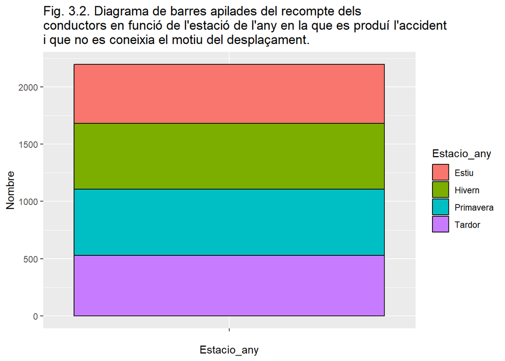

```r
dadesDesconegut_['Estacio_any'] <- "Estiu"
dadesDesconegut_$Estacio_any[dadesDesconegut_$Mes_any <= 3] <- "Hivern"
dadesDesconegut_$Estacio_any[dadesDesconegut_$Mes_any > 3 & dadesDesconegut_$Mes_any <= 6] <- "Primavera"
dadesDesconegut_$Estacio_any[dadesDesconegut_$Mes_any > 9] <- 'Tardor'

aggEstacions <- aggregate(dadesDesconegut_$Numero_expedient,
                             by=dadesDesconegut_["Estacio_any"],
                             FUN=length)

ggplot(aggEstacions, aes(x="", y=x, fill=Estacio_any)) +
  geom_bar(width = 1, stat = "identity", color = "black") +
  ggtitle(glue("Fig. 3.2. Diagrama de barres apilades del recompte dels
conductors en funció de l'estació de l'any en la que es produí l'accident
i que no es coneixia el motiu del desplaçament.")) +
  xlab(glue("Estacio_any")) +
  ylab("Nombre")
```

```r
dadesDesconegut_$Tipus_vehicle_estandaritzat <- gsub("d'", "",
                                          dadesDesconegut_$Tipus_vehicle_estandaritzat)
dadesDesconegut_$Victimitzacio_est_ <- gsub("d'", "",
                                  dadesDesconegut_$Victimitzacio_est_)

dadesDesconegut_$Descripcio_causa_mediata <- gsub("d'", "",
                                  dadesDesconegut_$Descripcio_causa_mediata)

dadesDesconegut_$Nom_mes <- gsub("ç", "s", dadesDesconegut_$Nom_mes)

dadesDesconegut_$Tipus_vehicle_estandaritzat <-
  stri_trans_general(str = dadesDesconegut_$Tipus_vehicle_estandaritzat,
                   id = "Latin-ASCII")
dadesDesconegut_$Victimitzacio_est_ <-
  stri_trans_general(str = dadesDesconegut_$Victimitzacio_est_,
                   id = "Latin-ASCII")
dadesDesconegut_$Descripcio_causa_mediata <-
  stri_trans_general(str = dadesDesconegut_$Descripcio_causa_mediata,
                   id = "Latin-ASCII")
dadesDesconegut_$Nom_districte <-
  stri_trans_general(str = dadesDesconegut_$Nom_districte,
                   id = "Latin-ASCII")

varsSup <- c("Descripcio_sexe", "Tipus_vehicle_estandaritzat",
               "Victimitzacio_est_", "Nom_mes", "Nom_districte",
             "Descripcio_causa_mediata", "Estacio_any",
              "Victimes_CODIF", "Numero_morts",
             "Numero_lesionats_lleus", "Numero_lesionats_greus",
             "Numero_victimes", "Numero_vehicles_implicats",
               "Vehicles_CODIF", "VM2R_CODIF", "VM4R_CODIF",
             "V_no_permis_CODIF", "VUP_CODIF", "Interve_conductor_novell",
             "Edat_CODIF", "Edat", "Es_laborable", "Es_ocupacional")

dadesDesconegutSup <- dadesDesconegut_[varsSup]
```

Una vegada més, s’observa que entre ambdós subconjunts de dades no hi ha una diferència substancial en la distribució dels grups i sent en ambdós casos durant la primavera quan es comptabilitzen més conductors ferits, tot i que en el cas dels conductors dels que no es coneixia el motiu del seu desplaçament s’observa un lleu increment de la proporció per l’estació hivernal.

# 2 Modelització

En les conclusions de la [segona part](https://rpubs.com/ramirezjm/1210635) d’aquesta sèrie vam constatar tot un seguit de mancances en les modelitzacions i la seva acpacitat d’encert, sent possiblement un dels motius el fet que hi havia un nombre molt elevat de variables en joc. Per aquest motiu en aquest apartat cercarem, en primer lloc, bastir un model de classificació amb l’algoritme de la Regressió Logística que ens permeti identificar quines de les variables del total de 23 variables utilitzables són estadísticament rellevants per identificar la variable dependent “Es_mon_treball”. Posteriorment, a partir del resultat obtingut d’aquest primer algoritme, bastirem diversos models amb diversos tipus algoritmes com l’arbre de decisió sense poda o amb poda i amb diverses parametritzacions a més dels models del bosc aleatori i i el XGBoost.

## 2.1 Regressió logística

```r
dadesSup["EMT_recodificat"] <- ifelse(dadesSup$Es_mon_treball=="Si", 1, 0)

cols_ <- colnames(dadesSup)
df_dtype_ <- as.data.frame(sapply(dadesSup, class))

for (col in cols_){
  data_type <- paste(df_dtype_[col, 1])
  n_domini <- length(unique(dadesSup[, col]))

  if (data_type == "character"){
    dadesSup[, col] <- as.factor(dadesSup[, col])
  }
  else if (n_domini <= 2) {
    dadesSup[, col] <- as.factor(dadesSup[, col])
  }
}
```

```r
cols_ <- colnames(dadesDesconegutSup)
df_dtype_ <- as.data.frame(sapply(dadesDesconegutSup, class))

for (col in cols_){
  data_type <- paste(df_dtype_[col, 1])
  n_domini <- length(unique(dadesDesconegutSup[, col]))

  if (data_type == "character"){
    dadesDesconegutSup[, col] <- as.factor(dadesDesconegutSup[, col])
  }
  else if (n_domini <= 2) {
    dadesDesconegutSup[, col] <- as.factor(dadesDesconegutSup[, col])
  }
}
```

```r
model <- glm(EMT_recodificat ~ Descripcio_sexe + Tipus_vehicle_estandaritzat +
               Descripcio_causa_mediata + Estacio_any + Numero_morts +
               Numero_lesionats_lleus + Numero_lesionats_greus +
               Numero_vehicles_implicats +
               Victimitzacio_est_ + Nom_mes + Nom_districte + Victimes_CODIF +
              Vehicles_CODIF + VM2R_CODIF + VM4R_CODIF + V_no_permis_CODIF +
               VUP_CODIF + Interve_conductor_novell + Edat_CODIF +
               Es_laborable + Es_ocupacional,
                data=dadesSup, family=binomial(link=logit), na.action = NULL)

summary(model)
```

```
##
## Call:
## glm(formula = EMT_recodificat ~ Descripcio_sexe + Tipus_vehicle_estandaritzat +
##     Descripcio_causa_mediata + Estacio_any + Numero_morts + Numero_lesionats_lleus +
##     Numero_lesionats_greus + Numero_vehicles_implicats + Victimitzacio_est_ +
##     Nom_mes + Nom_districte + Victimes_CODIF + Vehicles_CODIF +
##     VM2R_CODIF + VM4R_CODIF + V_no_permis_CODIF + VUP_CODIF +
##     Interve_conductor_novell + Edat_CODIF + Es_laborable + Es_ocupacional,
##     family = binomial(link = logit), data = dadesSup, na.action = NULL)
##
## Coefficients: (3 not defined because of singularities)
##                                                                   Estimate
## (Intercept)                                                      -1.623438
## Descripcio_sexeHome                                               0.051411
## Tipus_vehicle_estandaritzatVehicles motoritzats de quatre rodes   0.147854
## Tipus_vehicle_estandaritzatVehicles sense permis de conduccio    -0.178543
## Tipus_vehicle_estandaritzatVehicles Us Professional               4.507553
## Descripcio_causa_mediataCanvi de carril sense precaucio          -0.222134
## Descripcio_causa_mediataDesobeir altres senyals                  -0.399778
## Descripcio_causa_mediataDesobeir semafor                         -0.141734
## Descripcio_causa_mediataEnvair calcada contraria                 -1.184195
## Descripcio_causa_mediataFallada mecanica o avaria               -10.846365
## Descripcio_causa_mediataGir indegut o sense precaucio            -0.344420
## Descripcio_causa_mediataManca atencio a la conduccio             -0.293120
## Descripcio_causa_mediataManca precaucio efectuar marxa enrera    -0.350007
## Descripcio_causa_mediataManca precaucio incorporacio circulacio  -0.196837
## Descripcio_causa_mediataNo cedir la dreta                        -0.173525
## Descripcio_causa_mediataNo respectar distancies                  -0.514447
## Descripcio_causa_mediataNo respectat pas de vianants              0.188462
## Estacio_anyHivern                                                 0.082389
## Estacio_anyPrimavera                                              0.407298
## Estacio_anyTardor                                                -0.151417
## Numero_morts1                                                     1.516120
## Numero_lesionats_lleus                                           -0.008265
## Numero_lesionats_greus                                            0.205673
## Numero_vehicles_implicats                                        -0.037874
## Victimitzacio_est_Hospitalitzacio fins a 24h                      0.151513
## Victimitzacio_est_Hospitalitzacio superior a 24h                 -0.486056
## Victimitzacio_est_Mort                                           -1.099844
## Victimitzacio_est_Rebutja assistencia sanitaria                   0.284616
```

[output cut: 210 more lines]

```
## Edat_CODIFConductors entre 30 i 37 anys edat                    0.433426
## Edat_CODIFConductors fins 29 anys edat                          0.045354 *
## Edat_CODIFConductors majors de 49 anys edat                     0.595952
## Es_laborableSi                                                  8.35e-08 ***
## Es_ocupacionalSi                                                 < 2e-16 ***
## ---
## Signif. codes:  0 '***' 0.001 '**' 0.01 '*' 0.05 '.' 0.1 ' ' 1
##
## (Dispersion parameter for binomial family taken to be 1)
##
##     Null deviance: 3900.6  on 2822  degrees of freedom
## Residual deviance: 3435.1  on 2766  degrees of freedom
## AIC: 3549.1
##
## Number of Fisher Scoring iterations: 10
```

Si establim que el llindar per acceptar la variable és 0.05 > valor-p (*Pr(>|z|)*) per considerar-les que tenen un valor explicatiu estadísticament rellevant, atès als resultats hauríem d’excloure totes les cinc variables numèriques i acceptar només nou de les variables que enumerem en aquesta taula:

| Nom de la variable | Descripció de la variable |
| --- | --- |
| “Tipus_vehicle_estandaritzat” | Estandarització en només quatre categories de la variable “Tipus_vehicle”: “Vehicles d’ús professional”, “Vehicles motoritzats de quatre rodes”, “Vehicles motoritzats de dues rodes” i “Vehicles sense … |
| “Descripcio_causa_mediata” | Detalla la causa mediata identificada per la corresponent patrulla de la Guàrdia Urbana que fer l’atestat de l’accident, fent referència al tipus de maniobra o circumstància immediata que va causar l’… |
| “Estacio_any” | Trimestre de l’any en que va tenir lloc l’accident. |
| “Nom_mes” | Mes de l’any en que va tenir lloc l’accident. |
| “Victimes_CODIF” | Estableix si va haver-hi dos o més víctimes en l’accident. |
| “Vehicles_CODIF” | Estableix si va haver-hi dos o més vehicles implicats en l’accident. |
| “Edat_CODIF” | Codificació de grups d’edat a partir dels valors interquartils: menors de 29 anys, més dels 29 fins els 37 anys, més dels 37 fins els 49 anys i majors de 49 anys. |
| “Es_laborable” | Estableix si la data de l’accident era laborable durant l’any 2023. |
| “Es_ocupacional” | Estableix si l’hora de l’accident va ser dins d’una franja horària ocupacional, des de les 5 fins les 16h, en un dia laboral. |

També comprovem quin grau d’encert o precisió té aquest model al comprovar amb les mateixes dades amb les que s’ha entrenat, mesurant també la seva sensitivitat - o grau per encertar que sí es desplaçava per un motiu relacionat amb el món del treball- i especificitat - o grau per encertar que no es desplaçava per un motiu relacionat amb el món del treball:

```r
pred <- predict(model, newdata=dadesSup, type='response')

dadesSup$prediction <- ifelse(pred < 0.5 ,0, 1)
prediccio <- as.factor(dadesSup$prediction)
valor_esperat <- dadesSup$EMT_recodificat

tb <- table(valor_esperat, prediccio); tb
```

```
##              prediccio
## valor_esperat    0    1
##             0 1060  447
##             1  496  820
```

```r
# TN: tb[1]
# FP: tb[2]
# FN: tb[3]
# TP: tb[4]

# accuracy
precisio <- (tb[4] + tb[1]) / (tb[1] + tb[2] + tb[3] + tb[4])
print(glue("\n\nLa precisió de la predicció és {round(precisio, 4)}."))
```

```
##
## La precisió de la predicció és 0.666.
```

```r
# sensitivity
sensitivitat <- tb[4] / (tb[4] + tb[3])
print(glue("\n\nLa sensitivitat de la predicció és {round(sensitivitat, 4)}."))
```

```
##
## La sensitivitat de la predicció és 0.6472.
```

```r
# specifity
especificitat <- tb[1] / (tb[1] + tb[2])
print(glue("\n\nLa especificitat de la predicció és {round(especificitat, 4)}."))
```

```
##
## La especificitat de la predicció és 0.6812.
```

Observem que té una moderada capacitat predictiva tot i que l’especificitat és força superior a la seva sensitivitat, tret que acostuma ser un indicador de sobreajust del model. Per aquest motiu com també pel fet que l’objectiu d’emprar aquest algoritme de regressió logística era poder escollir, a partir de la seva significància estadística, quines variables tenen potencialment capacitat predictora i, per tant, no s’ha testejat amb una part de les dades que no hagi format part del model, el descartarem.

Per altra banda, també observem que dues de les variables - “Nom_mes” i “Estacio_any”- deriva l’una de l’altra però codificada de manera diferent, millorant apreciablement la capacitat predictiva dels modes de classificació que presentarem tot seguit en el cas de l’algorisme *XGBoost*; en canvi, s’observa que no és el cas pels models d’Arbre de decisió.

## 2.2 XGBoost (*eXtreme Gradient Boosting*)

A continuació posem en pràctica l’algorisme de *XGBoost* tot seguint l’exemple descrit en l’obra de P. Bruce, A. Bruce i P. Gedeck per treballara amb algorismes de *boosting* (BRUCE; BRUCE i GEDECK, 2022: 263-265), tal i com proposàvem en les conclusions de la [segona part](https://rstudio-pubs-static.s3.amazonaws.com/1210635_de2722e2828045228bc539cedf4a5fb7.html#exercici-7), aplicant-hi el fluxe de treball per automatitzar la sel·lecció del model més óptim tal i com proposa [T. Pham en *RPubs*](https://rpubs.com/pmtam/XGboost) per, posteriorment, fer-ne la [predicció corresponent](https://stackoverflow.com/a/70074206) amb el conjunt de dades dels conductors accidentats dels qui desconeixem el motiu del seu desplaçament:

```r
data.xgb <- dadesSup[, c("Tipus_vehicle_estandaritzat",
                       "Descripcio_causa_mediata", "Estacio_any",
                       "Nom_mes", "Victimes_CODIF", "Vehicles_CODIF",
                       "Edat_CODIF", "Es_laborable", "Es_ocupacional",
                     "Es_mon_treball")]

set.seed(123)
cust_split <- data.xgb %>%
  initial_split(prop = 0.8, strata = Es_mon_treball)

train <- training(cust_split)
test <- testing(cust_split)

# Cross validation folds from training dataset
set.seed(234)
folds <- vfold_cv(train, strata = Es_mon_treball)

cust_rec <- recipe(Es_mon_treball ~., data = train) %>%
#  update_role(customerID, new_role = "ID") %>%
#  step_corr(all_numeric()) %>%
  step_corr(all_numeric(), threshold = 0.7, method = "spearman") %>%
  step_zv(all_numeric()) %>% # filter zero variance
  step_normalize(all_numeric()) %>%
  step_dummy(all_nominal_predictors())
```

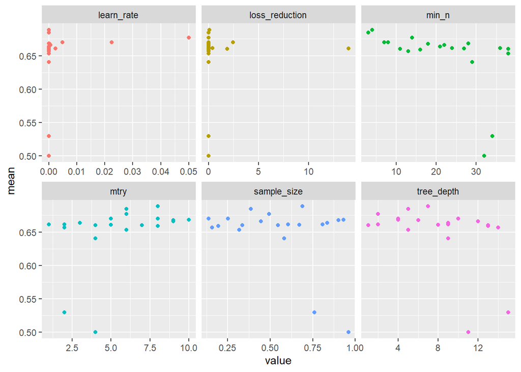

```r
# Setup a model specification
xgb_spec <-boost_tree(
  trees = 500,
  tree_depth = tune(),
  min_n = tune(),
  loss_reduction = tune(),                    ## first three: model complexity
  sample_size = tune(), mtry = tune(),        ## randomness
  learn_rate = tune()                         ## step size
) %>%
  set_engine("xgboost") %>%
  set_mode("classification")

xgb_wf <- workflow() %>%
  add_formula(Es_mon_treball ~.) %>%
  add_model(xgb_spec)

xgb_grid <- grid_latin_hypercube(
  tree_depth(),
  min_n(),
  loss_reduction(),
  sample_size = sample_prop(),
  finalize(mtry(), train),
  learn_rate(),
  size = 20
)

doParallel::registerDoParallel()

set.seed(234)
xgb_res <-tune_grid(
  xgb_wf,
  resamples = folds,
  grid = xgb_grid,
  control = control_grid(save_pred  = TRUE)
)

xgb_res %>%
  collect_metrics() %>%
  filter(.metric == "roc_auc") %>%
  select(mean, mtry:sample_size) %>%
  pivot_longer(mtry:sample_size,
               names_to = "parameter",
               values_to = "value") %>%
  ggplot(aes(value, mean, color = parameter)) +
  geom_point(show.legend = FALSE)+
  facet_wrap(~parameter, scales = "free_x")
```

```r
show_best(xgb_res)
```

```
## # A tibble: 5 × 12
##    mtry min_n tree_depth    learn_rate loss_reduction sample_size .metric
##   <int> <int>      <int>         <dbl>          <dbl>       <dbl> <chr>
## 1     8     4          7 0.00000000628    0.0985            0.690 roc_auc
## 2     6     3          5 0.0000366        0.000384          0.386 roc_auc
## 3     6    14          2 0.0500           0.0000364         0.492 roc_auc
## 4     8     7          4 0.0224           2.45              0.136 roc_auc
## 5     5     8         10 0.00495          0.000000579       0.251 roc_auc
## # ℹ 5 more variables: .estimator <chr>, mean <dbl>, n <int>, std_err <dbl>,
## #   .config <chr>
```

```r
best_auc <- select_best(xgb_res)
final_xgb <- finalize_workflow(xgb_wf, best_auc)

final_rs <- last_fit(final_xgb, cust_split,
                     metrics = metric_set(accuracy, roc_auc, sens,spec))
final_rs %>%
  collect_metrics()
```

```
## # A tibble: 4 × 4
##   .metric  .estimator .estimate .config
##   <chr>    <chr>          <dbl> <chr>
## 1 accuracy binary         0.663 Preprocessor1_Model1
## 2 sens     binary         0.699 Preprocessor1_Model1
## 3 spec     binary         0.621 Preprocessor1_Model1
## 4 roc_auc  binary         0.703 Preprocessor1_Model1
```

```r
final_wf <- final_rs %>%
  extract_workflow()

desconegutsPred <- dadesDesconegutSup[, c("Tipus_vehicle_estandaritzat",
                       "Descripcio_causa_mediata", "Estacio_any",
                       "Nom_mes", "Victimes_CODIF", "Vehicles_CODIF",
                       "Edat_CODIF", "Es_laborable", "Es_ocupacional")]

prediction.xgb <- predict(final_wf, desconegutsPred)
table(prediction.xgb)
```

```
## .pred_class
##   No   Si
## 1128 1068
```

## 2.3 Arbre de decisió (*Decision tree*)

A continuació, bastirem un model de classificació mitjançant l’algorisme de l’Arbre de decisió del módul C50 de R sense realitzar-ne cap poda ni cap canvi en els seu paràmetres per defecte:

En primer lloc, ho comprovarem incloent-hi també la variable “Nom_mes”:

```r
dummy[] <- lapply(dummy, factor)
colsExcloses <- c("VUP_CODIF", "VM2R_CODIF", "VM4R_CODIF", "V_no_permis_CODIF",
                  "Interve_conductor_novell", "Nom_districte",
                  "Descripcio_sexe", "Victimitzacio_est_", "Edat",
                  "Es_mon_treball", "prediction", "Numero_morts",
             "Numero_lesionats_lleus", "Numero_lesionats_greus",
             "Numero_victimes", "Numero_vehicles_implicats",
             "EMT_recodificat")

y <- dummy$Es_mon_treball
colsSup <- !colnames(dummy) %in% colsExcloses
x <- dummy[colsSup]

split_prop <- 5
indexes = sample(1:nrow(dummy),
                 size=floor(((split_prop-1)/split_prop)*nrow(dummy)))
train_x <- x[indexes, ]
train_y <- y[indexes]
test_x <- x[-indexes, ]
test_y <- y[-indexes]
```

```r
model1 <- C50::C5.0(train_x, train_y, rules=TRUE)
summary(model1)
```

```
##
## Call:
## C5.0.default(x = train_x, y = train_y, rules = TRUE)
##
##
## C5.0 [Release 2.07 GPL Edition]      Sun Aug 18 18:25:23 2024
## -------------------------------
##
## Class specified by attribute `outcome'
##
## Read 2258 cases (10 attributes) from undefined.data
##
## Rules:
##
## Rule 1: (1193/387, lift 1.3)
##  Tipus_vehicle_estandaritzat in {Vehicles motoritzats de 2 rodes,
##                                         Vehicles motoritzats de quatre rodes,
##                                         Vehicles sense permis de conduccio}
##  Es_ocupacional = No
##  ->  class No  [0.675]
##
## Rule 2: (62/2, lift 2.1)
##  Tipus_vehicle_estandaritzat = Vehicles Us Professional
##  ->  class Si  [0.953]
##
## Rule 3: (1021/404, lift 1.3)
##  Es_ocupacional = Si
##  ->  class Si  [0.604]
##
## Default class: No
##
##
## Evaluation on training data (2258 cases):
##
##          Rules
##    ----------------
##      No      Errors
##
##       3  793(35.1%)   <<
##
##
##     (a)   (b)    <-classified as
##    ----  ----
##     806   406    (a): class No
##     387   659    (b): class Si
##
##
##  Attribute usage:
##
##   98.05% Es_ocupacional
##   55.58% Tipus_vehicle_estandaritzat
##
##
## Time: 0.0 secs
```

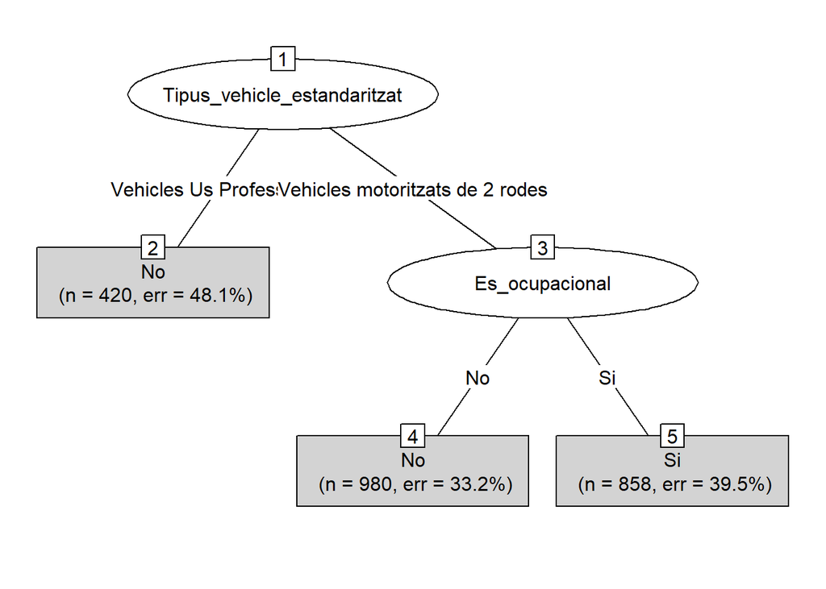

```r
model1 <- C50::C5.0(train_x, train_y)
plot(model1, type="s", title="Fig. 4. Arbre de decisió sense podar.")
```

```r
predicted_model1 <- predict(model1, test_x, type="class")

print(sprintf("La precisió de l'arbre sense podar és del %.4f %%.",
              100*sum(predicted_model1 == test_y) / length(predicted_model1)))
```

```
## [1] "La precisió de l'arbre sense podar és del 67.7876 %."
```

```r
mat_conf <- table(test_y, Predicted=predicted_model1); mat_conf
```

```
##       Predicted
## test_y  No  Si
##     No 208  87
##     Si  95 175
```

```r
# TN: mat_conf[1]
# FP: mat_conf[2]
# FN: mat_conf[3]
# TP: mat_conf[4]

# sensitivity
sensitivitat <- mat_conf[4] / (mat_conf[4] + mat_conf[3])
print(glue("\n\nLa sensitivitat de la predicció és {round(sensitivitat, 4)}."))
```

```
##
## La sensitivitat de la predicció és 0.6679.
```

```r
# specifity
especificitat <- mat_conf[1] / (mat_conf[1] + mat_conf[2])
print(glue("\n\nL'especificitat de la predicció és {round(especificitat, 4)}."))
```

```
##
## L'especificitat de la predicció és 0.6865.
```

I ara realitzarem la prova sense incloure-la:

```r
train_x_ <- x[indexes, !colnames(x) %in% c("Nom_mes")]
colnames(train_x)
```

```
## [1] "Tipus_vehicle_estandaritzat" "Nom_mes"
## [3] "Descripcio_causa_mediata"    "Estacio_any"
## [5] "Victimes_CODIF"              "Vehicles_CODIF"
## [7] "Edat_CODIF"                  "Es_laborable"
## [9] "Es_ocupacional"
```

```r
train_y <- y[indexes]
test_x_ <- x[-indexes, !colnames(x) %in% c("Nom_mes")]
test_y <- y[-indexes]

model1 <- C50::C5.0(train_x_, train_y, rules=TRUE)
summary(model1)
```

```
##
## Call:
## C5.0.default(x = train_x_, y = train_y, rules = TRUE)
##
##
## C5.0 [Release 2.07 GPL Edition]      Sun Aug 18 18:25:23 2024
## -------------------------------
##
## Class specified by attribute `outcome'
##
## Read 2258 cases (9 attributes) from undefined.data
##
## Rules:
##
## Rule 1: (1193/387, lift 1.3)
##  Tipus_vehicle_estandaritzat in {Vehicles motoritzats de 2 rodes,
##                                         Vehicles motoritzats de quatre rodes,
##                                         Vehicles sense permis de conduccio}
##  Es_ocupacional = No
##  ->  class No  [0.675]
##
## Rule 2: (62/2, lift 2.1)
##  Tipus_vehicle_estandaritzat = Vehicles Us Professional
##  ->  class Si  [0.953]
##
## Rule 3: (1021/404, lift 1.3)
##  Es_ocupacional = Si
##  ->  class Si  [0.604]
##
## Default class: No
##
##
## Evaluation on training data (2258 cases):
##
##          Rules
##    ----------------
##      No      Errors
##
##       3  793(35.1%)   <<
##
##
##     (a)   (b)    <-classified as
##    ----  ----
##     806   406    (a): class No
##     387   659    (b): class Si
##
##
##  Attribute usage:
##
##   98.05% Es_ocupacional
##   55.58% Tipus_vehicle_estandaritzat
##
##
## Time: 0.0 secs
```

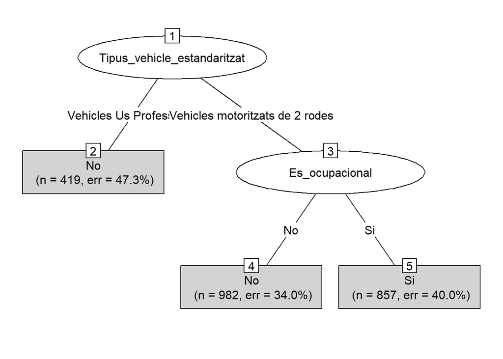

```r
model1 <- C50::C5.0(train_x_, train_y)
plot(model1, type="s", title="Fig. 5. Arbre de decisió sense podar.")
```

En aquest cas, amb l’arbre de decisió sense podar s’observa una notable millora en la seva intel·legibilitat en contrast als models d’arbre de decisió bastits en la [segona part](https://rstudio-pubs-static.s3.amazonaws.com/1210635_de2722e2828045228bc539cedf4a5fb7.html#exercici-5), constatant-se que el model primordialment fa servir les variables “Tipus_vehicle_estandarditzat” i “Es_ocupacional” per realitzar la classificació.

```r
predicted_model1 <- predict(model1, test_x, type="class")

print(sprintf("La precisió de l'arbre sense podar és del %.4f %%.",
              100*sum(predicted_model1 == test_y) / length(predicted_model1)))
```

```
## [1] "La precisió de l'arbre sense podar és del 67.7876 %."
```

```r
mat_conf <- table(test_y, Predicted=predicted_model1); mat_conf
```

```
##       Predicted
## test_y  No  Si
##     No 208  87
##     Si  95 175
```

```r
# TN: mat_conf[1]
# FP: mat_conf[2]
# FN: mat_conf[3]
# TP: mat_conf[4]

# sensitivity
sensitivitat <- mat_conf[4] / (mat_conf[4] + mat_conf[3])
print(glue("\n\nLa sensitivitat de la predicció és {round(sensitivitat, 4)}."))
```

```
##
## La sensitivitat de la predicció és 0.6679.
```

```r
# specifity
especificitat <- mat_conf[1] / (mat_conf[1] + mat_conf[2])
print(glue("\n\nL'especificitat de la predicció és {round(especificitat, 4)}."))
```

```
##
## L'especificitat de la predicció és 0.6865.
```

```r
predictions <- predict( model1, desconegutsPred, type="class" )

table(predictions)
```

```
## predictions
##   No   Si
## 1043 1153
```

Per altra banda, observem aproximadament sí segueix la proporció observable en l’anterior figura 1.2, tot i que la similitud del resultat ens suggereix també cert sobreajust en aquest model de classificació.

## 2.4 Arbre de decisió amb parametrització diferent

Realitzarem a continuació el mateix arbre de decisió però forçant que realitzi fins 99 iteracions a fi que escolleixi les prediccions més òptimes en cadascuna:

```r
nTrials <-99

model_nTrials <- C50::C5.0(train_x, train_y, trials = nTrials)

predicted_modelnTrials <- predict(model_nTrials, test_x, type="class")

print(sprintf("La precisió de l'arbre amb 99 iteracions és del %.4f %%.",
              100*sum(predicted_modelnTrials == test_y) / length(predicted_modelnTrials)))
```

```
## [1] "La precisió de l'arbre amb 99 iteracions és del 66.0177 %."
```

```r
mat_conf <- table(test_y, Predicted=predicted_modelnTrials); mat_conf
```

```
##       Predicted
## test_y  No  Si
##     No 233  62
##     Si 130 140
```

```r
# TN: mat_conf[1]
# FP: mat_conf[2]
# FN: mat_conf[3]
# TP: mat_conf[4]

# sensitivity
sensitivitat <- mat_conf[4] / (mat_conf[4] + mat_conf[3])
print(glue("\n\nLa sensitivitat de la predicció és {round(sensitivitat, 4)}."))
```

```
##
## La sensitivitat de la predicció és 0.6931.
```

```r
# specifity
especificitat <- mat_conf[1] / (mat_conf[1] + mat_conf[2])
print(glue("\n\nL'especificitat de la predicció és {round(especificitat, 4)}."))
```

```
##
## L'especificitat de la predicció és 0.6419.
```

```r
predictions <- predict(model_nTrials, desconegutsPred, type="class")

table(predictions)
```

```
## predictions
##   No   Si
## 1387  809
```

## 2.5 Bosc aleatori (*Random forest*)

Tot seguit, també bastim un model de classificació del Bosc aleatoriq ue realitzarà 500 iteracions sobre el conjunt de dades d’entrenament:

```r
library(rpart)
colsExcloses <- c("VUP_CODIF", "VM2R_CODIF", "VM4R_CODIF", "V_no_permis_CODIF",
                  "Interve_conductor_novell", "Nom_districte",
                  "Descripcio_sexe", "Victimitzacio_est_", "Edat",
                  "Es_mon_treball", "prediction", "Numero_morts",
             "Numero_lesionats_lleus", "Numero_lesionats_greus",
             "Numero_victimes", "Numero_vehicles_implicats",
             "EMT_recodificat")

colsSup <- !colnames(dummy) %in% colsExcloses

x <- dummy[colsSup]
y <- dummy$Es_mon_treball

rf <- randomForest(y ~., data = x); rf
```

```
##
## Call:
##  randomForest(formula = y ~ ., data = x)
##                Type of random forest: classification
##                      Number of trees: 500
## No. of variables tried at each split: 3
##
##         OOB estimate of  error rate: 37.76%
## Confusion matrix:
##     No  Si class.error
## No 968 539   0.3576642
## Si 527 789   0.4004559
```

```r
mat_conf <- rf$confusion

# sensitivity
sensitivitat <- mat_conf[4] / (mat_conf[4] + mat_conf[3])
print(glue("\n\nLa sensitivitat de la predicció és {round(sensitivitat, 4)}."))
```

```
##
## La sensitivitat de la predicció és 0.5941.
```

```r
especificitat <- mat_conf[1] / (mat_conf[1] + mat_conf[2])
print(glue("\n\nLa especificitat de la predicció és {round(especificitat, 4)}."))
```

```
##
## La especificitat de la predicció és 0.6475.
```

```r
predictions.rf <- predict( rf, desconegutsPred, type="class" )

table(predictions.rf)
```

```
## predictions.rf
##   No   Si
## 1092 1104
```

Es constata que el resultat del model és pitjor que l’anterior on havíem modificat la parametrització amb 99 iteracions atès a que la sensitivitat és inferior i l’especificitat ha augmentat, indicant-nos risc de sobreajust, tot i que també cal observar que el resultat de la predicció és molt similar al de les proporcions descrites en l’anterior Figura 1.2

## 2.6 Arbre de decisió podat (*Prune tree*)

Finalment, també provarem amb el mètode de l’arbre podat que ja vam possar en pràctica en la segona part. en aquest cas, ens limitarem a bastir el model mitjançant la funció tree() del módul Rpart de tal manera que seleccioni les tres branques que dinin un resultat més òptim.

```r
dummy <- dadesSup

dummy[] <- lapply(dummy, factor)
colsExcloses <- c("VUP_CODIF", "VM2R_CODIF", "VM4R_CODIF", "V_no_permis_CODIF",
                  "Interve_conductor_novell", "Nom_districte",
                  "Descripcio_sexe", "Victimitzacio_est_", "Edat",
                  "prediction", "Numero_morts",
             "Numero_lesionats_lleus", "Numero_lesionats_greus",
             "Numero_victimes", "Numero_vehicles_implicats",
             "EMT_recodificat")


colsSup <- !colnames(dummy) %in% colsExcloses
dummy_ <- dummy[colsSup]

split <- createDataPartition(y=dummy_$Es_mon_treball, p=4/5, list=FALSE)

train <- dummy_[split,]
test <- dummy_[-split,]

trees <- tree(Es_mon_treball~., train)
```

```r
prune.trees <- prune.tree(trees, best=3)
```

```r
tree.pred <- predict(prune.trees, test, type='class')
confusionMatrix(tree.pred, test$Es_mon_treball, positive = "Si")
```

```
## Confusion Matrix and Statistics
##
##           Reference
## Prediction  No  Si
##         No 207  92
##         Si  94 171
##
##                Accuracy : 0.6702
##                  95% CI : (0.6297, 0.7089)
##     No Information Rate : 0.5337
##     P-Value [Acc > NIR] : 3.121e-11
##
##                   Kappa : 0.3377
##
##  Mcnemar's Test P-Value : 0.9415
##
##             Sensitivity : 0.6502
##             Specificity : 0.6877
##          Pos Pred Value : 0.6453
##          Neg Pred Value : 0.6923
##              Prevalence : 0.4663
##          Detection Rate : 0.3032
##    Detection Prevalence : 0.4699
##       Balanced Accuracy : 0.6689
##
##        'Positive' Class : Si
##
```

```r
prediction.prune.tree <- predict(prune.trees, desconegutsPred, type='class')
table(prediction.prune.tree)
```

```
## prediction.prune.tree
##   No   Si
## 1043 1153
```

# 3 Elecció del model

En primer lloc presentarem la Taula amb els resultats més rellevants d’aquesta tercera part per, a continuació, justificar l’elecció del resultat del model *XGBoost*.

## 3.1 Taula de resultats

Només es detallaran els indicadors de precisió dels models de regressió logística, *XGBoost* i de l’arbre podat atès que en tots tres casos el model resultant és prou robust, es a dir, no mostra una variabilitat apreciable en els seus resultats.

[output not shown]

## 3.2 Justificació

En aquesta tercera part d’aquesta tasca de classificació dels conductors ferits en accidents de trànsit durant l’any 2023, en certa mesura ens hem centrat a realitzar en la pràctica una imputació per aquells 2196 conductors dels qui es desconeixia el motiu del seu desplaçament. La rellevància de realitzar aquesta imputació la trobem en el fet que aquests representaven fins el 43% del total de conductors feris i dels qui disposàvem d’un joc complet de dades vàlides (v. fila #3 en Taula de resultats). Una proporció tant elevada tornava com poc fiable la variable del *motiu dels desplaçament* pel seu anàlisi però, amb la tasca realitzada fins ara valorem que sí podria ser ja utilitzable com una variable més per enriquir l’estudi les tendències en els accidents de trànsit amb ferits en els que hi intervingueren agents de la Guàrdia Urbana de Barcelona.

També cal valorar com rellevants les variables acceptades per la seva significància estadística per explicar el resultat que, en aquest cas, és indicar “Si”/“No” per cada conductor en relació a si el motiu del seu desplaçament en el moment de ser partícep en el corresponent accident documentat tenia relació amb el món del treball - v. detall del significat d’aquesta variable en la primera part d’aquest estudi-, no només per que l’agorisme corresponent el valori estadísticament òptim, si no també per que resulten coherents amb allò que coneixem del món del treball. Resulta congruent que el tipus de vehicle - especialment els vehicles d’ús professional- o el fet que l’accident tingui lloc durant un dia laborable i un horari ocupacional siguin rellevants si el desplaçament era per un motiu laboral. Per altra banda, ja de forma més intuïtiva també resulta coherent que hi siguin rellevants l’edat - significament, amb una codificació que limita l’efecte dels *outliers* o valors extrems- o en quin mes o estació de l’any va tenir lloc. I, desde una perspectiva analítica i per la seva posterior interpretació, resulta d’interès que el nombre de víctimes, el nombre de vehicles implicats i la causa mediata de l’accident també tinguin una capacitat explicativa relllevant.

# 4 Bibliografia

- **BRUCE, P.; BRUCE, A.; i GEDECK, P. 2022**. *Estadística práctica para ciencia de datos con R y Python*, Barcelona: Marcombo.
- **INSTITUT METRÒPOLI. 2023**. *Enquesta de mobilitat en dia feiner 2023. (EMEF 2023)*, Barcelona: Autoritat del Transport Metropolità. [URL](https://bcnroc.ajuntament.barcelona.cat/jspui/bitstream/11703/136649/2/EMEF%202023_Informe%20SIMMB%20ATM.pdf) (darrera visita el 13-VIII-2024).